# Quality of Antenatal Care Services

Malawi Demographic Health Survey Data - 2019

Richard Malirakwenda

2023-12-07

## Introduction

This is a brief report on the quality of Antenatal Care Services based on selected variables in the package of ANC services compared across different aspects. The variables selected were blood pressure measurement,urine test, administration of albendazole and administration of Iron. These ANC variables that determine quality were compared across other variables like region, facility, education level, age, residency type and age group. The Malawi Demographic Health Survey 2019 data was used to analyse the quality of ANC services in this context.

## Distribution of blood pressure measurement according to ANC timing initiation and age

The following chart shows the distribution of of women who had their blood pressure checked during antenatal period according to their age and the time they started antenatal care.The average age of women who had their blood pressure measured at the time they started antenatal care was around 29 years. Few women started antenatal care in the first month of their pregnancy compared to visits 2-6 where there were even more blodd pressure measurements.

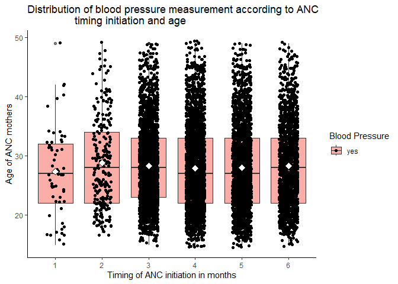

## Percentage of women by age group who reported to have either received Albendazole or not

The following chart shows proportion of women by age group who reported to have received albendazole tablets or not. Albendazole is a drug that is given to pregnant women after 16 weeks gestation to treat worm infestation. Findings show that the 20-24 age group received more albendazole than any other age group (55%). The 40-44 age group was the least of all the age groups (44%). However, there were no significant differences across all the age groups.

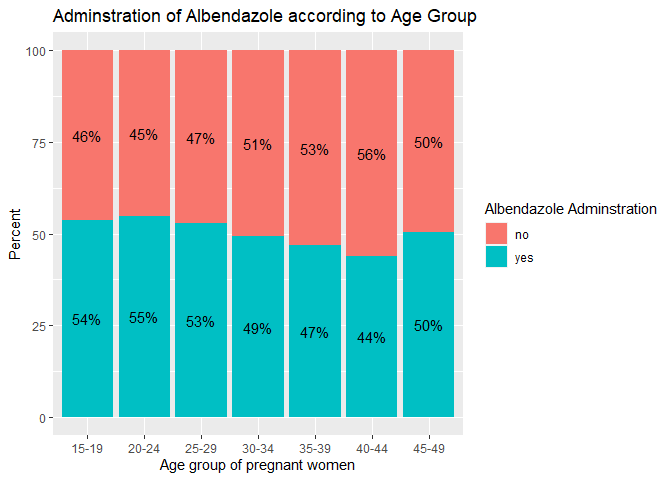

## Percentage of antenatal women who received iron according to region and Educational level.

The chart below shows the number of antenatal women who received Iron tablets according to region and education level. Iron is the type of medication given to antenatal mothers for prevention of anaemia. The chart shows that the percentage of antenatal women receiving iron was higher in the primary level category averaging 65% across all the regions compared to the rest of the of the education levels by region. There was low uptake of iron in Women who attained higher education in all the regions, averaging 2%.

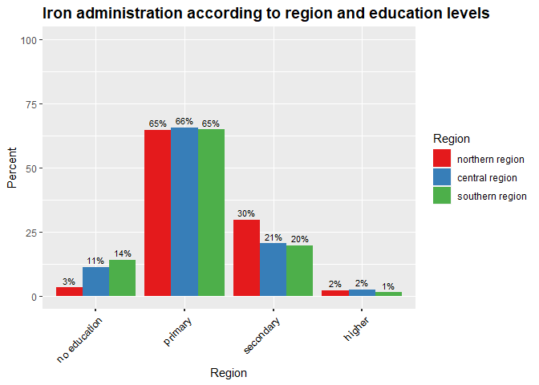

## Percentage of urine samples taken during antenatal care according to residency.

The following charts shows percentage of urine samples during antenatal care according to residency type, here being urban and rural. Among several indications, Urine sample is also taken during antenatal period to test levels of protein as marker for hypertensive disorder and presence of leukocytes as marker for urinary tract infections. The chart below shows that the percentage of women who had their urine samples taken was higher in urban than in rural, here represented as 42% and 32 % respectively. However, overall percentage of urine samples taken was low in both urban and rural,below 50%.

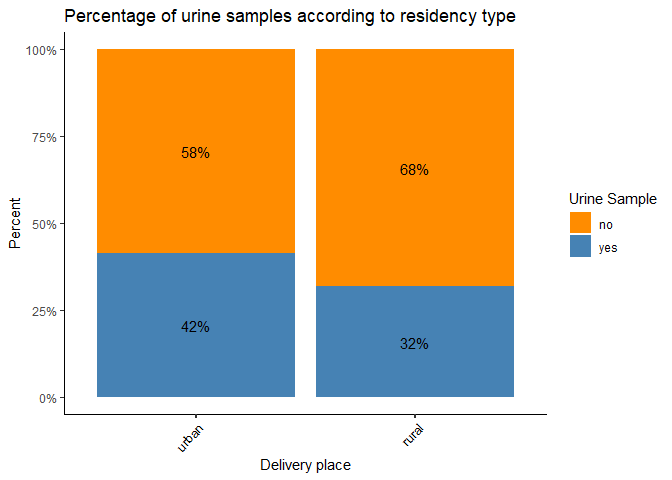